##### Observations

##### The Job Role “Sales Reps” has the lowest average duration at the company.

##### The Job Roles of Managers have the longest average duration at the company.

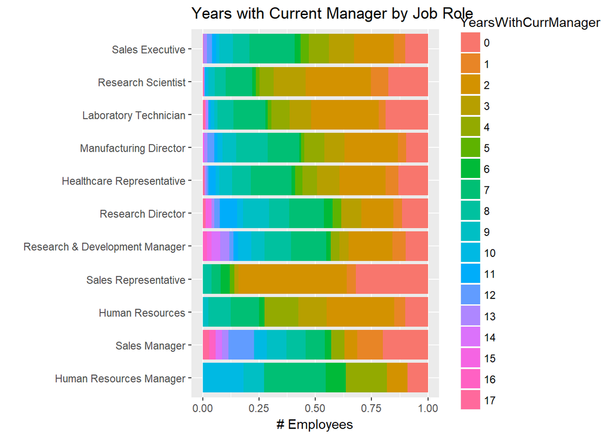

```r
 ggplot(data=as.data.frame(table(noattrit$JobRole,noattrit$YearsWithCurrManager,dnn=list("JobRole","YearsWithCurrManager"))), aes(x= reorder(JobRole,Freq),y=Freq, fill = YearsWithCurrManager)) + geom_bar(stat="identity",position="fill") + coord_flip() + ggtitle("Years with Current Manager by Job Role") + xlab("") + ylab("# Employees")
```

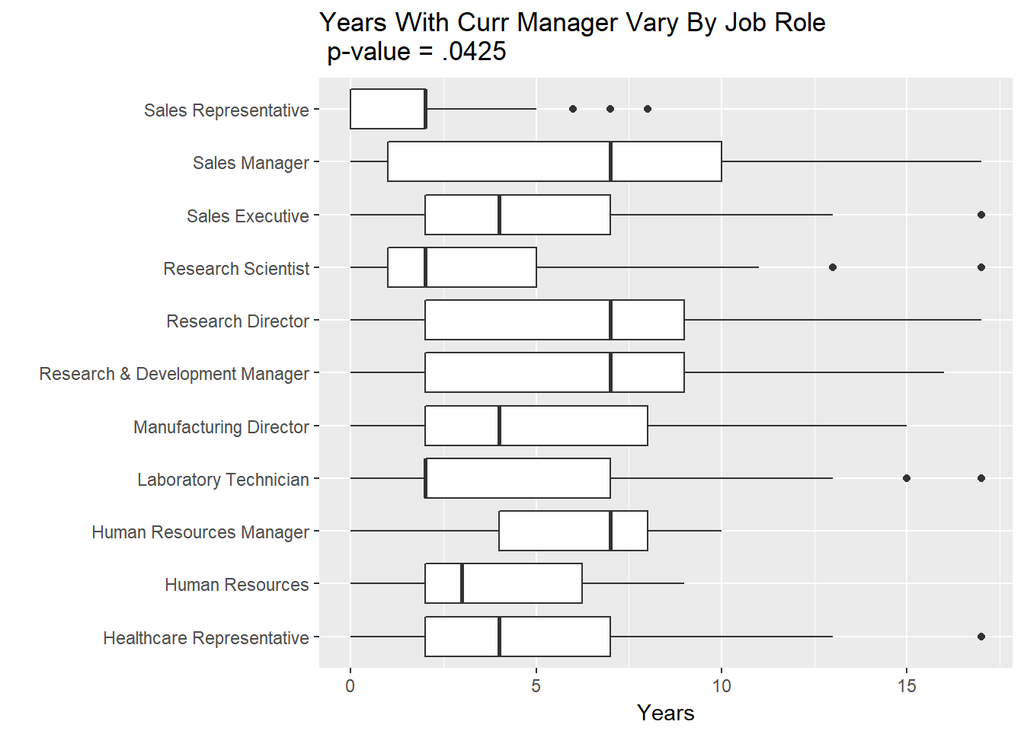

```r
ggplot(data=noattrit,aes(x= JobRole,y=YearsWithCurrManager)) + geom_boxplot() + coord_flip() + ggtitle("Years With Curr Manager Vary By Job Role \n p-value = .0425") + xlab("")+ylab("Years")
```

##### Observations:

##### Sales Reps change managers most frequently, while directors and managers tend to stay with the same manager for a longer time.

##### Education Level

##### Though not identified as a first order differentiator by linear regression, Education is an interesting parameter in regards to Job Role

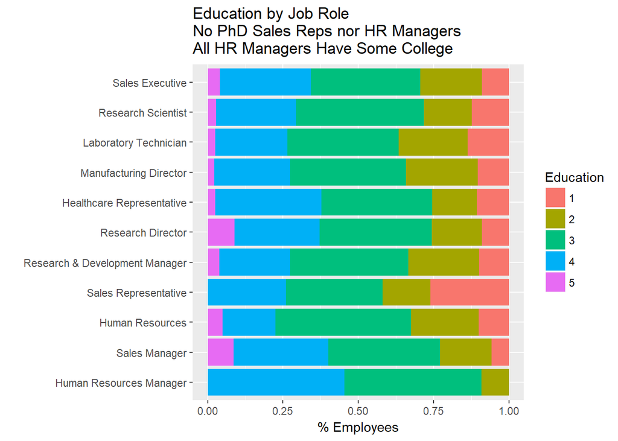

```r
ggplot(data=as.data.frame(table(noattrit$JobRole,noattrit$Education,dnn=list("JobRole","Education"))), aes(x= reorder(JobRole,Freq),y=Freq, fill = Education)) +
geom_bar(stat="identity",position="fill") + coord_flip() + ggtitle("Education by Job Role \nNo PhD Sales Reps nor HR Managers \nAll HR Managers Have Some College") + xlab("") + ylab("% Employees")
```

### Company Specifics

##### Key Findings

##### 67% of the Employees in the Company in R&D

##### The average age of employees in 37.56 years, with the employees in HR average age being slightly higher.

##### There are 46% more Male employees than Female employees. HR has the largest ratio of Males to Female at 2.6:1

##### Job Level is strongly correlated to Montly Income. High Job Level = Higher Monthly Incomes.

##### Human Resource Managers are the only Role which does not have ‘Low’ level of job involvement

##### 50% of Employees have been with the company <= 5 years

##### People with Marketing education only work in Sales, and people with HR education only work in HR. All departments have a mix of Educational Backgrounds.

##### Everyone receives a Performance Rating of Excellent or Outstanding.

##### Work Experience correlates to Job Level and therefore Monthly Income

##### Monthly Income is based on Work Experience, not Performance. (Job Level is correlated to Total Time Worked and Time At Company. Monthly Income is correlated to Job Level and Total Time Worked. All Performance Ratings are Excellent and Outstanding.)

##### The longer you work for a manager the longer the time between promotions.

##### Departments

```r
DepartmentDF <- as.data.frame(table(noattrit$Department))
colnames(DepartmentDF) <- c("Department","DepartmentCount")

DepartmentDF$CoDepartmntPercentage <-paste(100*as.numeric(format(DepartmentDF$DepartmentCount/colSums(DepartmentDF[2]),digits=1)),"%")
DepartmentDF$CoDepartmntPercentage <-paste(100*as.numeric(format(DepartmentDF$DepartmentCount/colSums(DepartmentDF[2]),digits=1)),"%")

 print.data.frame(DepartmentDF[with(DepartmentDF, order(-DepartmentCount)),],row.names=FALSE)
```

```
##              Department DepartmentCount CoDepartmntPercentage
##  Research & Development             828                  67 %
##                   Sales             354                  29 %
##         Human Resources              51                   4 %
```

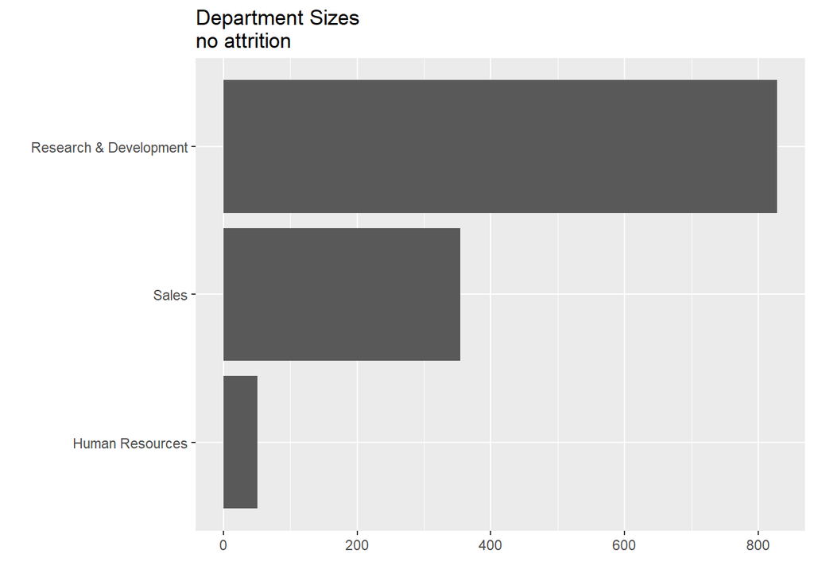

```r
ggplot(data=as.data.frame(table(noattrit$Department,dnn=list("Department"))), aes(x= reorder(Department,Freq),y=Freq)) +
geom_bar(stat="identity") + coord_flip() + ggtitle("Department Sizes \nno attrition") + xlab("") + ylab("")
```

##### Age Distribution

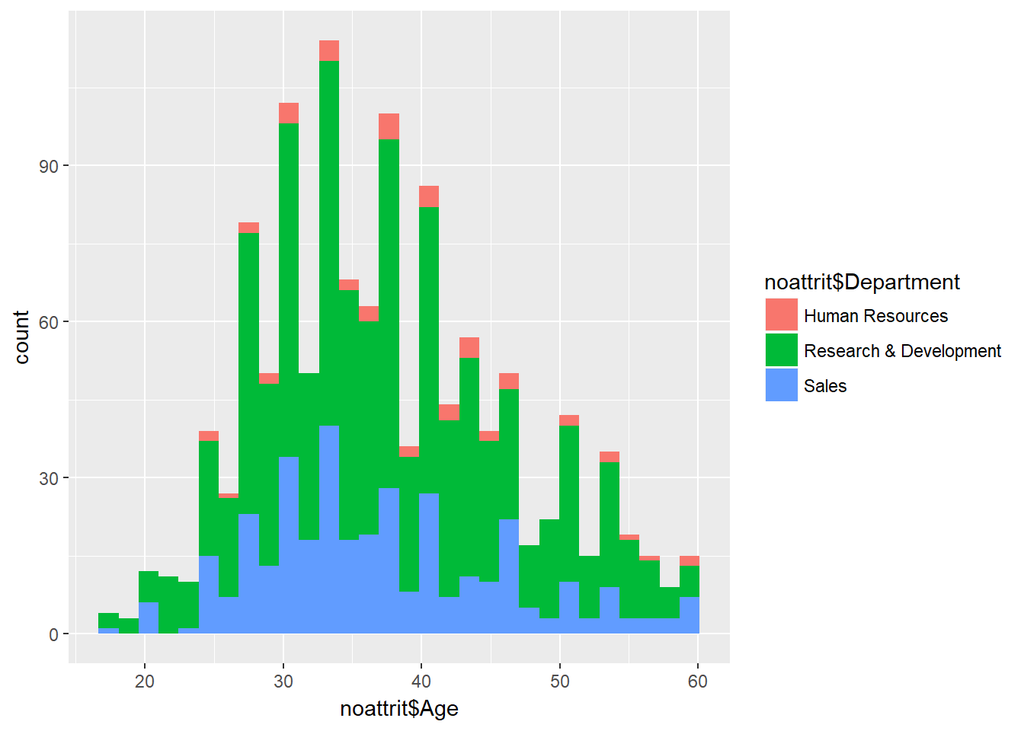

```r
options(width = 150)
ggplot(data=noattrit, aes(x=noattrit$Age,fill=noattrit$Department)) + geom_histogram()
```

```r
cat("Summary of Age Distribution for the Company")
```

```
## Summary of Age Distribution for the Company
```

```r
summary(noattrit$Age)
```

```
##    Min. 1st Qu.  Median    Mean 3rd Qu.    Max.
##   18.00   31.00   36.00   37.56   43.00   60.00
```

```r
cat("Summary of Age Distributions by Department")
```

```
## Summary of Age Distributions by Department
```

```r
aggdata <-aggregate(noattrit$Age, by=list(noattrit$Department),
FUN=summary, na.rm=TRUE)
print(aggdata)
```

```
##                  Group.1   x.Min. x.1st Qu. x.Median   x.Mean x.3rd Qu.   x.Max.
## 1        Human Resources 24.00000  33.50000 39.00000 39.62745  44.50000 59.00000
## 2 Research & Development 18.00000  31.00000 36.00000 37.61594  43.25000 60.00000
## 3                  Sales 18.00000  31.00000 36.00000 37.13559  42.75000 60.00000
```

##### Gender Distribution by Department

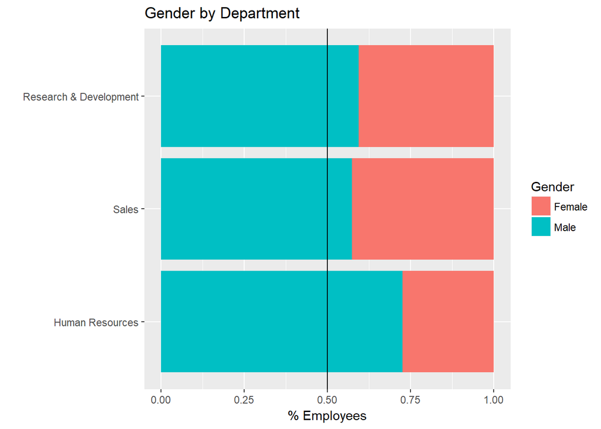

```r
ggplot(data=as.data.frame(table(noattrit$Department,noattrit$Gender,dnn=list("Department","Gender"))), aes(x= reorder(Department,Freq),y=Freq, fill = Gender)) + geom_bar(stat="identity",position="fill") + coord_flip() + ggtitle("Gender by Department") + xlab("") + ylab("% Employees") + geom_hline(data=noattrit, aes(yintercept = .50), colour="black")
```

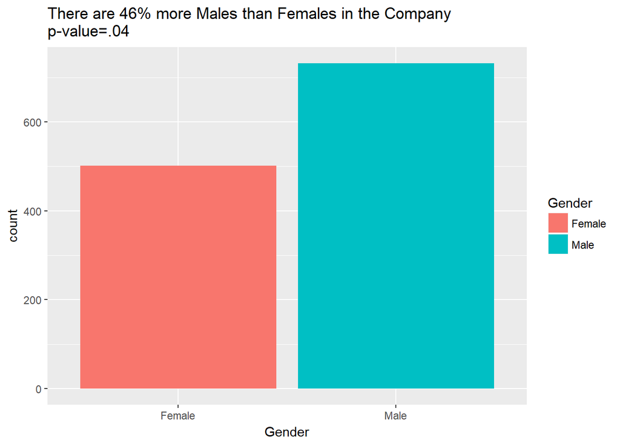

```r
ggplot(data=noattrit, aes(x=noattrit$Gender,fill=Gender)) + geom_bar() + ggtitle("There are 46% more Males than Females in the Company \np-value=.04") + xlab("Gender")
```

```r
#Recode Department to a numeric for t-test analysis
noattrit$DeptCode[noattrit$Department=="Research & Development"] <- 1L
noattrit$DeptCode[noattrit$Department=="Sales"] <- 2L
noattrit$DeptCode[noattrit$Department=="Human Resources"] <- 3L
t.test(table(noattrit$DeptCode, noattrit$Gender))
```

```
##
##  One Sample t-test
##
## data:  table(noattrit$DeptCode, noattrit$Gender)
## t = 2.7531, df = 5, p-value = 0.04016
## alternative hypothesis: true mean is not equal to 0
## 95 percent confidence interval:
##   13.62051 397.37949
## sample estimates:
## mean of x
##     205.5
```

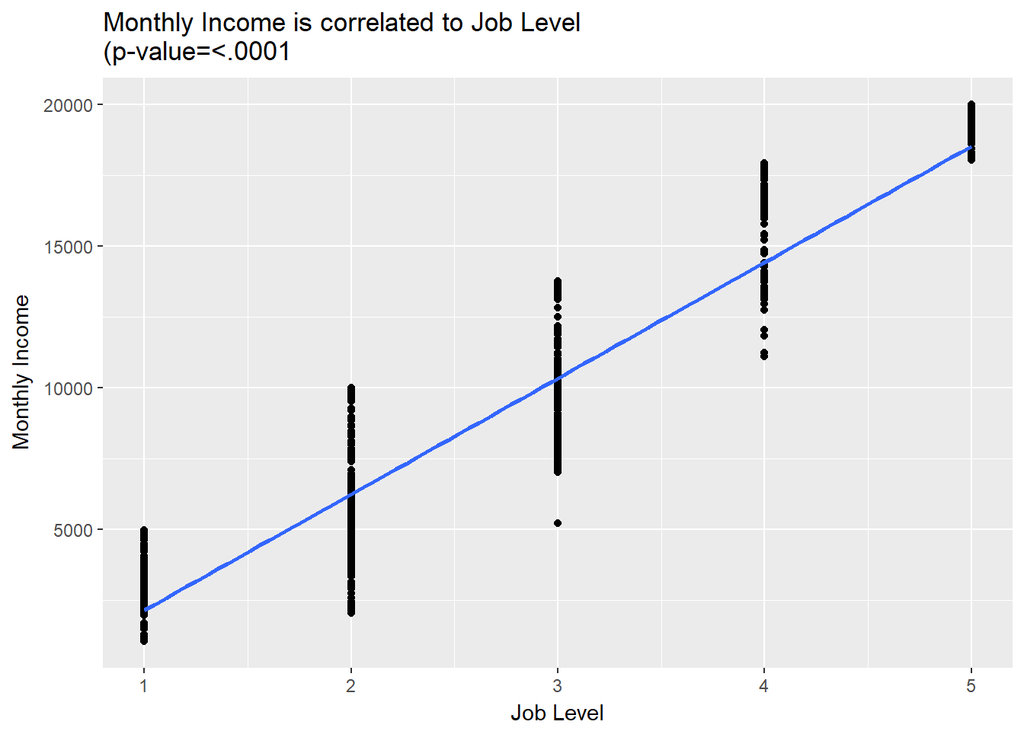

```r
ggplot(data=noattrit,aes(x=noattrit$JobLevel, y=noattrit$MonthlyIncome)) + geom_point()  + ggtitle("Monthly Income is correlated to Job Level \n(p-value=<.0001") + ylab("Monthly Income") +xlab("Job Level") + geom_smooth(method = 'lm', se = FALSE)
```

```r
results <- lm(noattrit$MonthlyIncome~noattrit$JobLevel)
summary(results)
```

```
##
## Call:
## lm(formula = noattrit$MonthlyIncome ~ noattrit$JobLevel)
##
## Residuals:
##     Min      1Q  Median      3Q     Max
## -5119.4 -1021.7   136.6   810.0  3763.0
##
## Coefficients:
##                   Estimate Std. Error t value Pr(>|t|)
## (Intercept)       -1953.62      92.83  -21.05   <2e-16 ***
## noattrit$JobLevel  4094.33      38.37  106.72   <2e-16 ***
## ---
## Signif. codes:  0 '***' 0.001 '**' 0.01 '*' 0.05 '.' 0.1 ' ' 1
##
## Residual standard error: 1505 on 1231 degrees of freedom
## Multiple R-squared:  0.9025, Adjusted R-squared:  0.9024
## F-statistic: 1.139e+04 on 1 and 1231 DF,  p-value: < 2.2e-16
```

##### Job Involvement

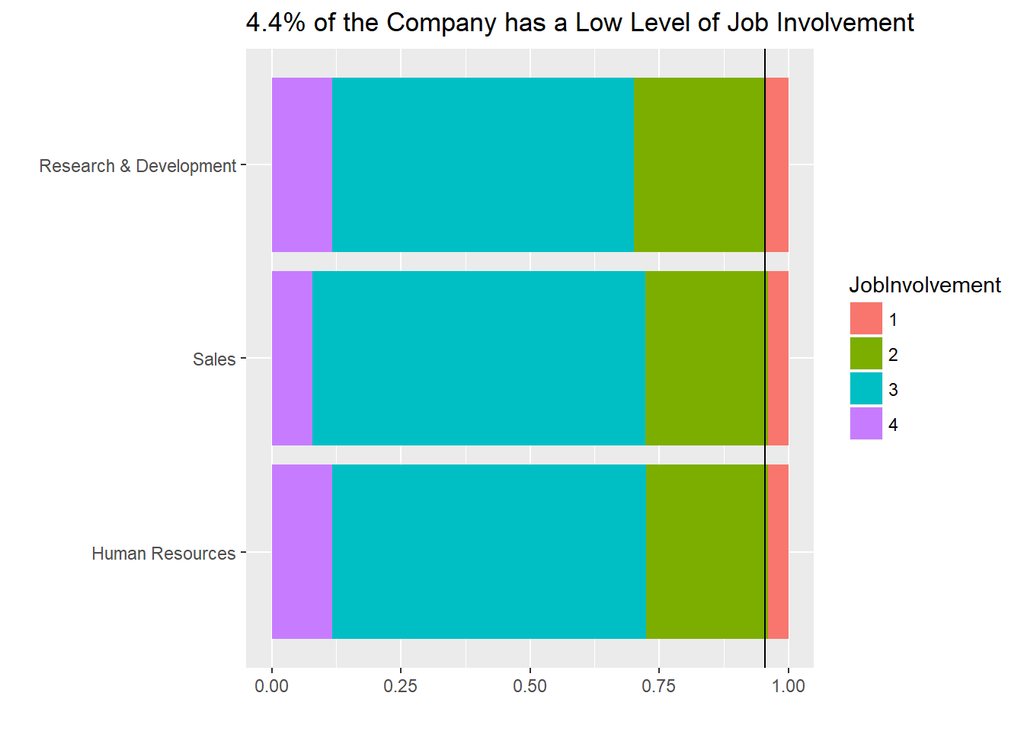

```r
 ggplot(data=as.data.frame(table(noattrit$Department,noattrit$JobInvolvement,dnn=list("Department","JobInvolvement"))), aes(x= reorder(Department,Freq),y=Freq, fill = JobInvolvement)) + geom_bar(stat="identity",position="fill") + coord_flip() + ggtitle("4.4% of the Company has a Low Level of Job Involvement") + xlab("") + ylab("") + geom_hline(data=noattrit, aes(yintercept = .9554), colour="black")
```

```r
t.test(table(noattrit$DeptCode, noattrit$JobInvolvement))
```

```
##
##  One Sample t-test
##
## data:  table(noattrit$DeptCode, noattrit$JobInvolvement)
## t = 2.5003, df = 11, p-value = 0.02949
## alternative hypothesis: true mean is not equal to 0
## 95 percent confidence interval:
##   12.29995 193.20005
## sample estimates:
## mean of x
##    102.75
```

#### Number of Years with Current Manager

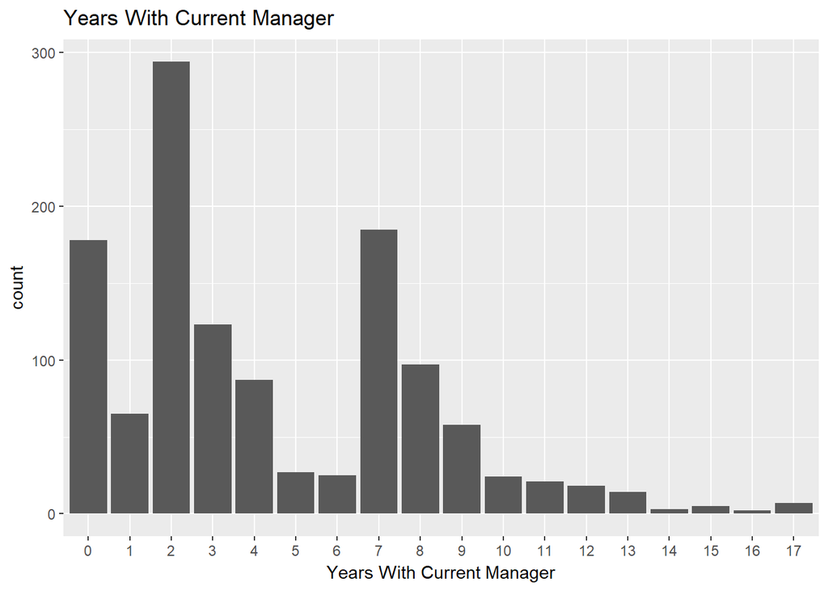

```r
ggplot(data=noattrit, aes(x=factor(noattrit$YearsWithCurrManager))) + geom_histogram(stat="count",position = "dodge") +xlab("Years") + scale_x_discrete(name='Years With Current Manager') + ggtitle("Years With Current Manager")
```

##### Observations:

##### Multiple Modal Distribution

##### Education

```r
cat("Percentage of Employees with No College-Level Education:",paste(100*as.numeric(format(nrow(as.data.frame(noattrit[( noattrit$Education == 1),]))/1233,digits=1)),"%"))
```

```
## Percentage of Employees with No College-Level Education: 10 %
```

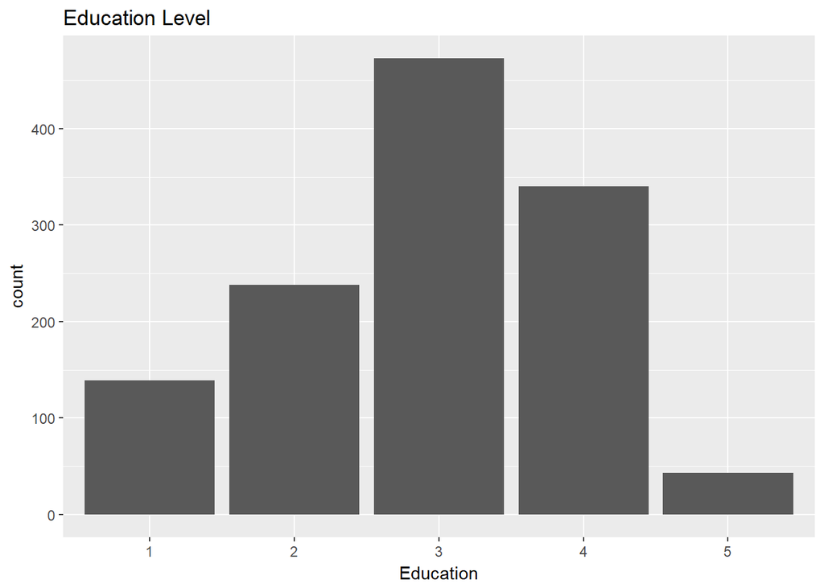

```r
ggplot(data=noattrit, aes(x=factor(noattrit$Education))) + geom_histogram(stat="count",position = "dodge") +xlab(" ") + scale_x_discrete(name='Education') + ggtitle("Education Level")
```

#### Compensation is based on Work Experience not Performance

##### Job Level vs Total Working Years

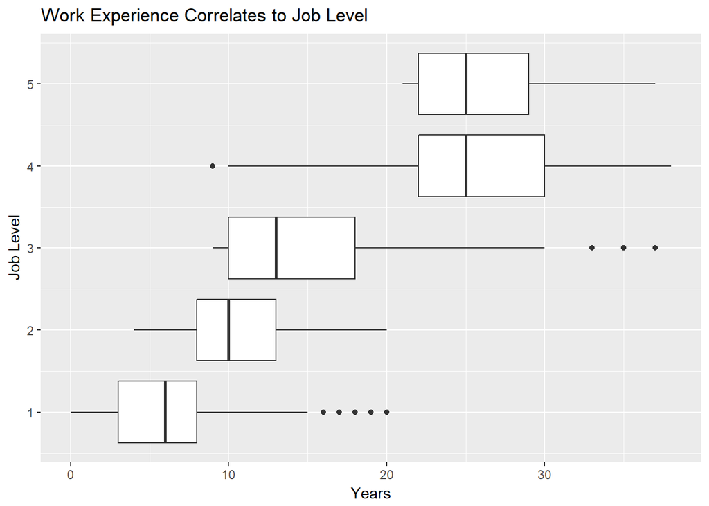

```r
ggplot(data=noattrit,aes(x= JobLevel,y=noattrit$TotalWorkingYears, group=JobLevel)) + geom_boxplot() + coord_flip() + ggtitle("Work Experience Correlates to Job Level") + xlab("Job Level")+ylab("Years")
```

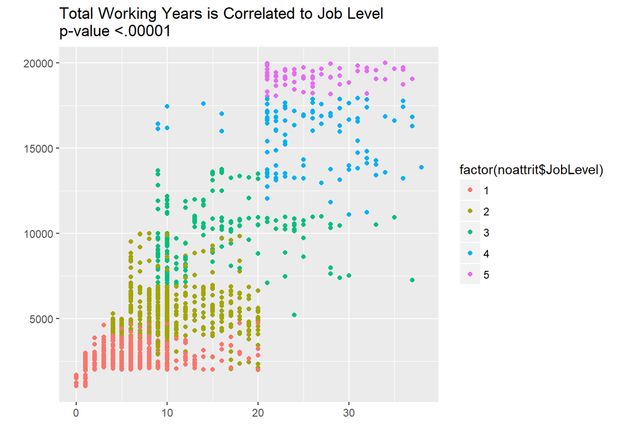

```r
ggplot(data=noattrit,aes(x=noattrit$TotalWorkingYears,
y=noattrit$MonthlyIncome,col=factor(noattrit$JobLevel))) +
geom_point()  + ggtitle("Total Working Years is Correlated to Job Level \np-value <.00001") + xlab("")+ylab("")
```

```r
results <- lm(noattrit$JobLevel~noattrit$TotalWorkingYears)
summary(results)
```

```
##
## Call:
## lm(formula = noattrit$JobLevel ~ noattrit$TotalWorkingYears)
##
## Residuals:
##      Min       1Q   Median       3Q      Max
## -2.06151 -0.48633  0.06362  0.40116  2.17613
##
## Coefficients:
##                            Estimate Std. Error t value Pr(>|t|)
## (Intercept)                0.811251   0.036340   22.32   <2e-16 ***
## noattrit$TotalWorkingYears 0.112513   0.002564   43.89   <2e-16 ***
## ---
## Signif. codes:  0 '***' 0.001 '**' 0.01 '*' 0.05 '.' 0.1 ' ' 1
##
## Residual standard error: 0.6984 on 1231 degrees of freedom
## Multiple R-squared:  0.6101, Adjusted R-squared:  0.6098
## F-statistic:  1926 on 1 and 1231 DF,  p-value: < 2.2e-16
```

#### Total Time At Company vs Monthly Income

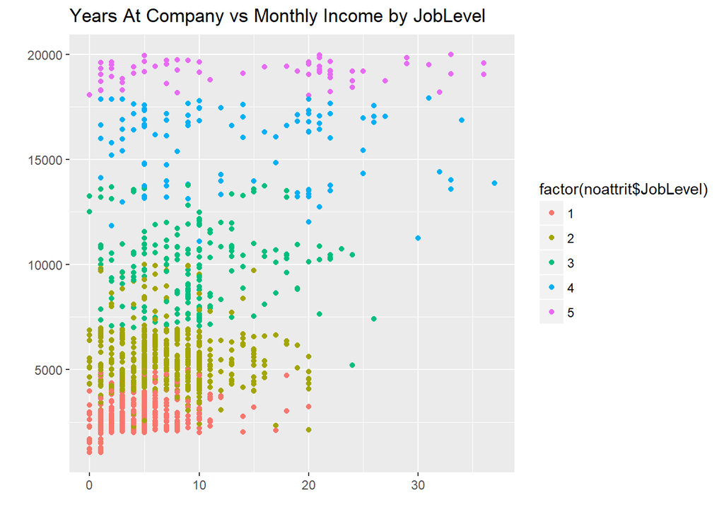

```r
ggplot(data=noattrit,aes(x=noattrit$YearsAtCompany, y=noattrit$MonthlyIncome,col=factor(noattrit$JobLevel))) +
geom_point()  + ggtitle("Years At Company vs Monthly Income by JobLevel") + xlab("")+ylab("")
```

```r
 results <- lm(noattrit$MonthlyIncome ~ noattrit$JobLevel + noattrit$TotalWorkingYears + noattrit$YearsAtCompany)
 summary(results)
```

```
##
## Call:
## lm(formula = noattrit$MonthlyIncome ~ noattrit$JobLevel + noattrit$TotalWorkingYears +
##     noattrit$YearsAtCompany)
##
## Residuals:
##     Min      1Q  Median      3Q     Max
## -5295.9 -1004.0    90.5   849.6  3964.0
##
## Coefficients:
##                             Estimate Std. Error t value Pr(>|t|)
## (Intercept)                -1943.842     92.416 -21.034  < 2e-16 ***
## noattrit$JobLevel           3848.637     60.956  63.138  < 2e-16 ***
## noattrit$TotalWorkingYears    53.394      9.388   5.688 1.61e-08 ***
## noattrit$YearsAtCompany      -15.735      8.680  -1.813   0.0701 .
## ---
## Signif. codes:  0 '***' 0.001 '**' 0.01 '*' 0.05 '.' 0.1 ' ' 1
##
## Residual standard error: 1487 on 1229 degrees of freedom
## Multiple R-squared:  0.905,  Adjusted R-squared:  0.9047
## F-statistic:  3901 on 3 and 1229 DF,  p-value: < 2.2e-16
```

##### Performance Rating

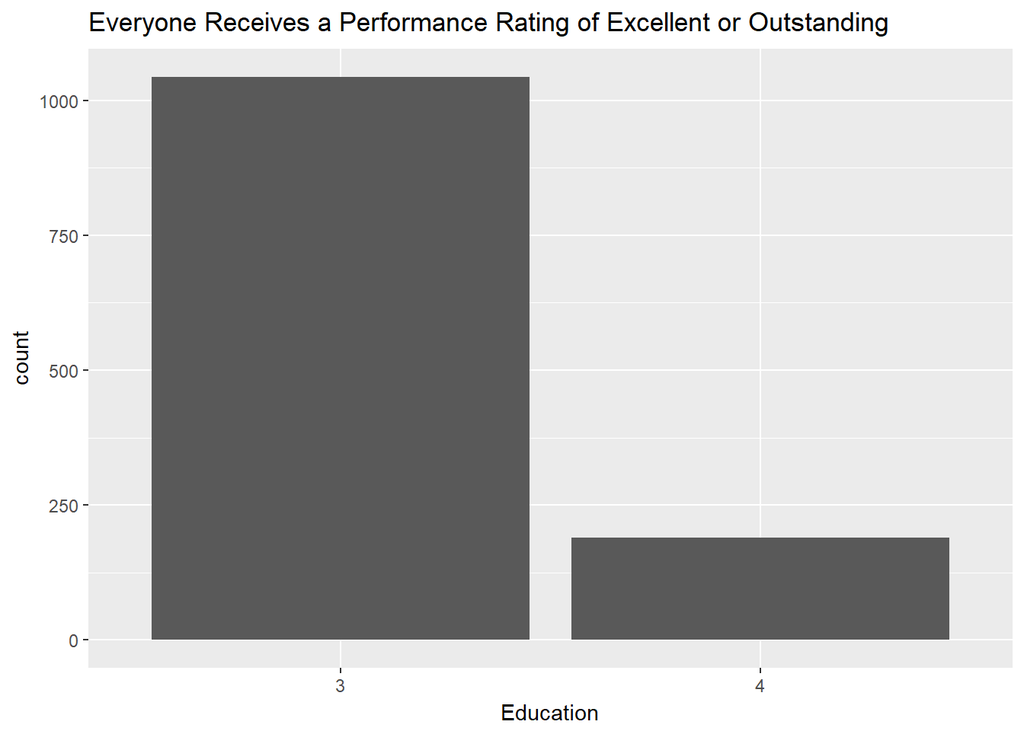

```r
ggplot(data=noattrit, aes(x=factor(noattrit$PerformanceRating))) + geom_histogram(stat="count",position = "dodge") +xlab(" ") + scale_x_discrete(name='Education') + ggtitle("Everyone Receives a Performance Rating of Excellent or Outstanding")
```

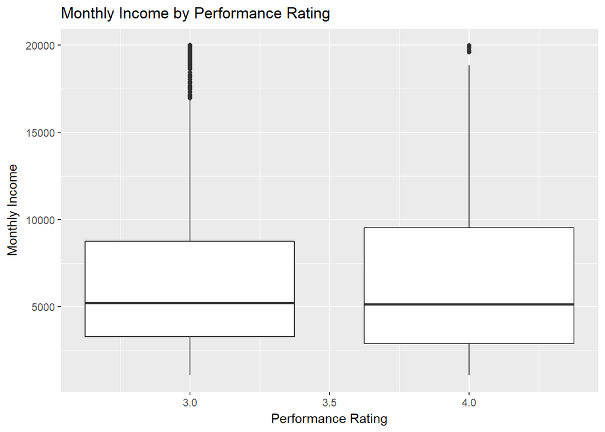

```r
ggplot(data=noattrit,aes(x= PerformanceRating, y=noattrit$MonthlyIncome, group=PerformanceRating)) + geom_boxplot() + ggtitle("Monthly Income by Performance Rating") + xlab("Performance Rating")+ylab("Monthly Income")
```

##### Years Since Promotion

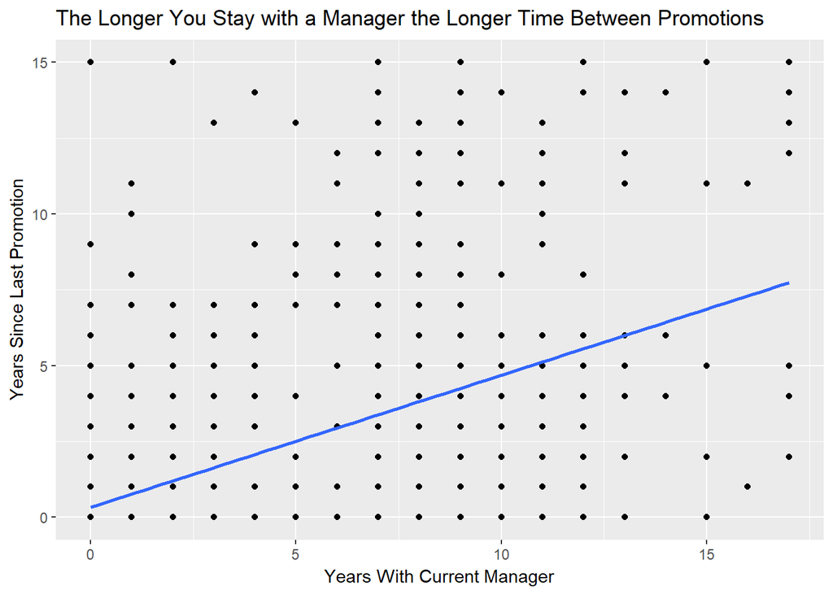

```r
ggplot(data=noattrit,aes(x=noattrit$YearsWithCurrManager, y=noattrit$YearsSinceLastPromotion)) +
geom_point()  + ggtitle("The Longer You Stay with a Manager the Longer Time Between Promotions") + xlab("Years With Current Manager")+ylab("Years Since Last Promotion") + stat_smooth(method="lm", se=FALSE)
```

```r
results <- lm(noattrit$YearsSinceLastPromotion ~ noattrit$YearsWithCurrManager)
summary(results)
```

```
##
## Call:
## lm(formula = noattrit$YearsSinceLastPromotion ~ noattrit$YearsWithCurrManager)
##
## Residuals:
##     Min      1Q  Median      3Q     Max
## -6.8662 -1.6387 -0.3318  0.7969 14.6682
##
## Coefficients:
##                               Estimate Std. Error t value Pr(>|t|)
## (Intercept)                    0.33183    0.12694   2.614  0.00906 **
## noattrit$YearsWithCurrManager  0.43563    0.02245  19.407  < 2e-16 ***
## ---
## Signif. codes:  0 '***' 0.001 '**' 0.01 '*' 0.05 '.' 0.1 ' ' 1
##
## Residual standard error: 2.832 on 1231 degrees of freedom
## Multiple R-squared:  0.2343, Adjusted R-squared:  0.2337
## F-statistic: 376.6 on 1 and 1231 DF,  p-value: < 2.2e-16
```

[figure not shown]

```r
ggplot(data=noattrit,aes(x= JobLevel,y=noattrit$YearsSinceLastPromotion, group=JobLevel)) + geom_boxplot() + coord_flip() + ggtitle("Time Since Last Promotion Increases as Job Level Increases") + xlab("Job Level")+ylab("Years")
```